# Reproducible Research - Course Project 1

Gagan Mathur

Wednesday, October 10, 2016

{This is an R Markdown document. Markdown is a simple formatting syntax for authoring HTML, PDF, and MS Word documents. For more details on using R Markdown see http://rmarkdown.rstudio.com.

# Peer-graded Assignment: Course Project 1

## Introduction

It is now possible to collect a large amount of data about personal movement using activity monitoring devices such as a Fitbit, Nike Fuelband, or Jawbone Up. These type of devices are part of the “quantified self” movement - a group of enthusiasts who take measurements about themselves regularly to improve their health, to find patterns in their behavior, or because they are tech geeks. But these data remain under-utilized both because the raw data are hard to obtain and there is a lack of statistical methods and software for processing and interpreting the data.

This assignment makes use of data from a personal activity monitoring device. This device collects data at 5 minute intervals through out the day. The data consists of two months of data from an anonymous individual collected during the months of October and November, 2012 and include the number of steps taken in 5 minute intervals each day.

The data for this assignment can be downloaded from the course web site: .Dataset: Activity monitoring data [52K]

The variables included in this dataset are: .steps: Number of steps taking in a 5-minute interval (missing values are coded as NA) .date: The date on which the measurement was taken in YYYY-MM-DD format .interval: Identifier for the 5-minute interval in which measurement was taken

The dataset is stored in a comma-separated-value (CSV) file and there are a total of 17,568 observations in this dataset.

### Review criteria

#### Repo

1.Valid GitHub URL 2.At least one commit beyond the original fork 3.Valid SHA-1 4.SHA-1 corresponds to a specific commit

#### Commit containing full submission

1.Code for reading in the dataset and/or processing the data 2.Histogram of the total number of steps taken each day 3.Mean and median number of steps taken each day 4.Time series plot of the average number of steps taken 5.The 5-minute interval that, on average, contains the maximum number of steps 6.Code to describe and show a strategy for imputing missing data 7.Histogram of the total number of steps taken each day after missing values are imputed 8.Panel plot comparing the average number of steps taken per 5-minute interval across weekdays and weekends 9.All of the R code needed to reproduce the results (numbers, plots, etc.) in the report

## Assignment

This assignment will be described in multiple parts. You will need to write a report that answers the questions detailed below. Ultimately, you will need to complete the entire assignment in a single R markdown document that can be processed by knitr and be transformed into an HTML file.

Throughout your report make sure you always include the code that you used to generate the output you present. When writing code chunks in the R markdown document, always use echo = TRUE so that someone else will be able to read the code. This assignment will be evaluated via peer assessment so it is essential that your peer evaluators be able to review the code for your analysis.

For the plotting aspects of this assignment, feel free to use any plotting system in R (i.e., base, lattice, ggplot2)

Fork/clone the GitHub repository created for this assignment. You will submit this assignment by pushing your completed files into your forked repository on GitHub. The assignment submission will consist of the URL to your GitHub repository and the SHA-1 commit ID for your repository state.

NOTE: The GitHub repository also contains the dataset for the assignment so you do not have to download the data separately.

## Loading and preprocessing the data

### Show any code that is needed to

#### 1.Load the data (i.e. read.csv())

```r
## Load libraries needed
library(stringr)

###############################################################################
## 1.Code for reading in the dataset and/or processing the data
###############################################################################

## Clean up R workspace of previously defined objects:
rm(list=ls())

## Set working directory:
setwd("C:/Users/gagan.mathur/OneDrive/Career/Data Science Specialization/Course 5 Reproducible Research/Course Project 1")

## Download Dataset: Activity Monitoring Data
## URL: https://d396qusza40orc.cloudfront.net/repdata%2Fdata%2Factivity.zip*
zipFile <- "ActivityMonitoringData.zip"; datFile <- "activity.csv"
download.file("https://d396qusza40orc.cloudfront.net/repdata%2Fdata%2Factivity.zip",zipFile)
fList <- unzip(zipFile)
```

#### 2.Process/transform the data (if necessary) into a format suitable for your analysis

```r
## Prepare Dataset:
df_Act_All <- read.csv(datFile)
df_Act_All$date <- as.Date(df_Act_All$date,format="%Y-%m-%d")
df_Act_All$sIntvl <- sprintf("%04d", df_Act_All$interval)
df_Act_All$hour <- substr(df_Act_All$sIntvl,1,2)
```

## What is mean total number of steps taken per day?

### For this part of the assignment, you can ignore the missing values in the dataset.

[output not shown]

```
## [1] 15264     5
```

```
## 'data.frame':    15264 obs. of  5 variables:
##  $ steps   : int  0 0 0 0 0 0 0 0 0 0 ...
##  $ date    : Date, format: "2012-10-02" "2012-10-02" ...
##  $ interval: int  0 5 10 15 20 25 30 35 40 45 ...
##  $ sIntvl  : chr  "0000" "0005" "0010" "0015" ...
##  $ hour    : chr  "00" "00" "00" "00" ...
```

```
##      steps             date               interval         sIntvl
##  Min.   :  0.00   Min.   :2012-10-02   Min.   :   0.0   Length:15264
##  1st Qu.:  0.00   1st Qu.:2012-10-16   1st Qu.: 588.8   Class :character
##  Median :  0.00   Median :2012-10-29   Median :1177.5   Mode  :character
##  Mean   : 37.38   Mean   :2012-10-30   Mean   :1177.5
##  3rd Qu.: 12.00   3rd Qu.:2012-11-16   3rd Qu.:1766.2
##  Max.   :806.00   Max.   :2012-11-29   Max.   :2355.0
##      hour
##  Length:15264
##  Class :character
##  Mode  :character
##
##
##
```

```
##     steps       date interval sIntvl hour
## 289     0 2012-10-02        0   0000   00
## 290     0 2012-10-02        5   0005   00
## 291     0 2012-10-02       10   0010   00
## 292     0 2012-10-02       15   0015   00
## 293     0 2012-10-02       20   0020   00
## 294     0 2012-10-02       25   0025   00
```

#### 1.Calculate the total number of steps taken per day

```r
df_steps_each_day <-aggregate(steps ~ date, data=df_Act, sum)
mean_steps_each_day <- round(mean(df_steps_each_day$steps))
median_steps_each_day <- round(median(df_steps_each_day$steps))
```

#### 2.If you do not understand the difference between a histogram and a barplot, research the difference between them. Make a histogram of the total number of steps taken each day

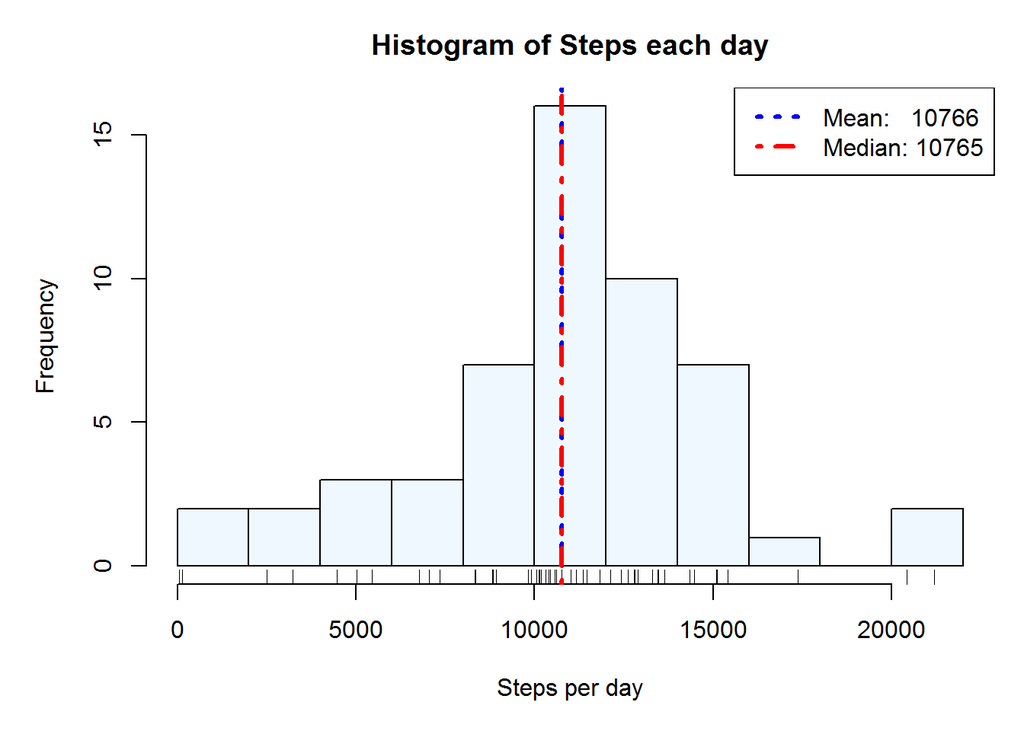

```r
## png(filename="plot1-1 Steps each day.png", width=640, height=480, units="px")
par(mfrow=c(1,1), mar=c(5,5,3,1))
hist(df_steps_each_day$steps, breaks=10, col="aliceblue", xlab="Steps per day", main="Histogram of Steps each day")
rug(df_steps_each_day$steps)
abline(v=mean_steps_each_day, col="blue", lwd=3, lty=3)
abline(v=median_steps_each_day, col="red", lwd=3, lty=4)
legend("topright", lwd=3, lty = c(3,4), col = c("blue", "red"),
       legend = c(paste("Mean:  ",mean_steps_each_day),
                  paste("Median:",median_steps_each_day)))
```

```r
## dev.off()
```

#### 3.Calculate and report the mean and median of the total number of steps taken per day

```r
###############################################################################
## 3.Mean and median number of steps taken each day
###############################################################################

print(paste("The mean number of steps taken each day is:", mean_steps_each_day))
```

```
## [1] "The mean number of steps taken each day is: 10766"
```

```r
print(paste("The median number of steps taken each day is:", median_steps_each_day))
```

```
## [1] "The median number of steps taken each day is: 10765"
```

## What is the average daily activity pattern?

#### 1.Make a time series plot (i.e. type = “l”) of the 5-minute interval (x-axis) and the average number of steps taken, averaged across all days (y-axis)

```r
###############################################################################
## 4.Time series plot of the average number of steps taken
###############################################################################

df_avg_steps_per_interval <-aggregate(steps ~ interval, data=df_Act, mean)
df_avg_steps_per_date <-aggregate(steps ~ date, data=df_Act, mean)
df_avg_steps_per_hour <-aggregate(steps ~ hour, data=df_Act, mean)
dim(df_avg_steps_per_interval); dim(df_avg_steps_per_date); dim(df_avg_steps_per_hour)
```

```
## [1] 288   2
```

```
## [1] 53  2
```

```
## [1] 24  2
```

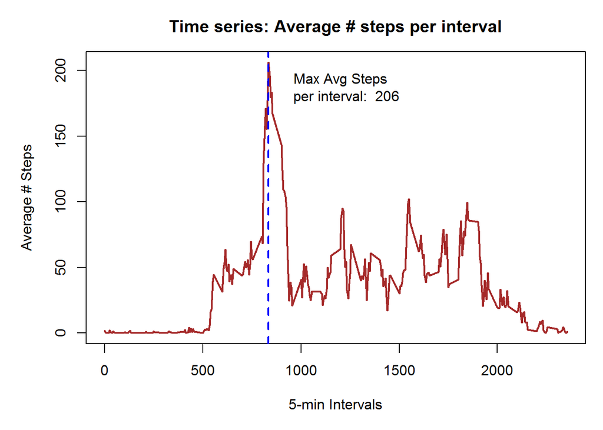

```r
## png(filename="plot1-2 Avg# Steps per Interval.png", width=640, height=480, units="px")
par(mfrow=c(1,1), mar=c(5,5,3,1))
with(df_avg_steps_per_interval,
     plot(interval, steps, type="l", col="brown", lwd=2,
          main="Time series: Average # steps per interval",
          ylab="Average # Steps", xlab="5-min Intervals")
)
maxRow <- df_avg_steps_per_interval[which.max(df_avg_steps_per_interval$steps),]
maxRow$steps <- round(maxRow$steps,0)
abline(v=maxRow[1], col="blue", lwd=2, lty=2)
text(x=maxRow[1]*1.1, y=maxRow[2]*0.9, paste("Max Avg Steps \nper interval: ", round(maxRow[2],0)), pos=4)
```

```r
## dev.off()

min(df_Act$interval); max(df_Act$interval)
```

```
## [1] 0
```

```
## [1] 2355
```

#### 2.Which 5-minute interval, on average across all the days in the dataset, contains the maximum number of steps?

```r
print("Below is the data corresponding to 5 min interval containig maximum number of steps:")
```

```
## [1] "Below is the data corresponding to 5 min interval containig maximum number of steps:"
```

```r
maxRow
```

```
##     interval steps
## 104      835   206
```

## Imputing missing values

### Note that there are a number of days/intervals where there are missing values (coded as NA). The presence of missing days may introduce bias into some calculations or summaries of the data.

#### 1.Calculate and report the total number of missing values in the dataset (i.e. the total number of rows with NAs)

```r
n_total <- nrow(df_Act_All)
n_missing <- nrow(df_Act_All[is.na(df_Act_All$steps),])
n_valid <- nrow(df_Act)
pct_missing <- round(n_missing*100/n_total,0)

print(paste0("There are ", n_total, " records, of which ", n_valid, " are valid and ", n_missing, " (", pct_missing, "%) are missing."))
```

```
## [1] "There are 17568 records, of which 15264 are valid and 2304 (13%) are missing."
```

#### 2.Devise a strategy for filling in all of the missing values in the dataset. The strategy does not need to be sophisticated. For example, you could use the mean/median for that day, or the mean for that 5-minute interval, etc.

The strategy I have chosen is to take mean number of steps by date, hour, 5-min interval. Replace any missing mean values by 0, and finally the missing values are replaced by a sum of alll these three mean values.

```r
###############################################################################
## 5.Imputing missing values
###############################################################################
library(data.table)

dt_Act_All <- data.table(df_Act_All)

dt_avg_per_intv <- data.table(df_avg_steps_per_interval)
dt_avg_per_date <- data.table(df_avg_steps_per_date)
dt_avg_per_hour <- data.table(df_avg_steps_per_hour)
head(dt_avg_per_hour)
```

```
##    hour      steps
## 1:   00  0.6509434
## 2:   01  0.4512579
## 3:   02  0.3317610
## 4:   03  0.3003145
## 5:   04  1.5597484
## 6:   05 11.6289308
```

```r
names(dt_avg_per_intv)[2] <- "mean_steps_per_intv"
names(dt_avg_per_date)[2] <- "mean_steps_per_date"
names(dt_avg_per_hour)[2] <- "mean_steps_per_hour"
```

#### 3.Create a new dataset that is equal to the original dataset but with the missing data filled in.

```r
## 1 Set JOIN key to join mean steps by interval:
setkey(dt_Act_All, interval)
setkey(dt_avg_per_intv, interval)

dt_Act_All <- merge(dt_Act_All,dt_avg_per_intv, all.x=TRUE)

## 2 Set JOIN key to join mean steps by date:
setkey(dt_Act_All, date)
setkey(dt_avg_per_date, date)

dt_Act_All <- merge(dt_Act_All,dt_avg_per_date, all.x=TRUE)

## 3 Set JOIN key to join mean steps by hour:
setkey(dt_Act_All, hour)
setkey(dt_avg_per_hour, hour)

dt_Act_All <- merge(dt_Act_All,dt_avg_per_hour, all.x=TRUE)

## Treat any missing values in means as 0:
dt_Act_All[is.na(mean_steps_per_date),]$mean_steps_per_date <- 0

## Fill in missing data:
dt_Act_All[is.na(steps),]$steps <-
  dt_Act_All[is.na(steps),]$mean_steps_per_date +
  dt_Act_All[is.na(steps),]$mean_steps_per_hour +
  dt_Act_All[is.na(steps),]$mean_steps_per_intv
## head(dt_Act_All[!complete.cases(df_Act_All),])
## dim(dt_Act_All)
## head(dt_Act_All[is.na(steps),])
```

#### 4.Make a histogram of the total number of steps taken each day and Calculate and report the mean and median total number of steps taken per day. Do these values differ from the estimates from the first part of the assignment? What is the impact of imputing missing data on the estimates of the total daily number of steps?

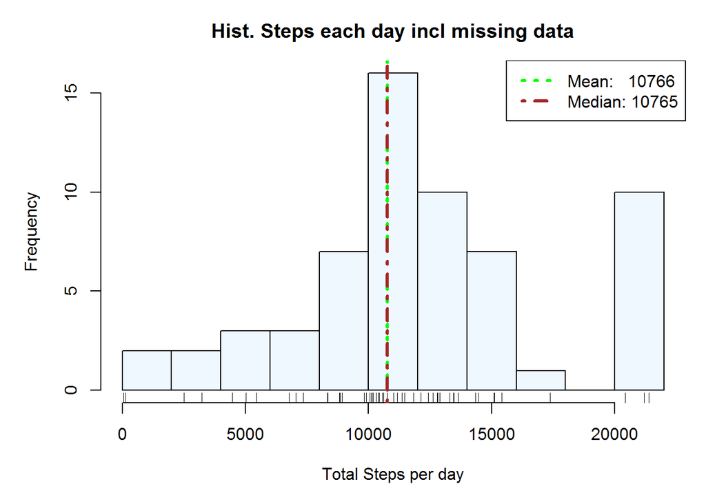

```r
## Make histogram again including missing data:
dt_all_steps_each_day <-aggregate(steps ~ date, data=dt_Act_All, sum)
mean_all_steps_each_day <- round(mean(df_steps_each_day$steps))
median_all_steps_each_day <- round(median(df_steps_each_day$steps))


## png(filename="plot1-3 All Steps each day.png", width=640, height=480, units="px")
par(mfrow=c(1,1), mar=c(5,5,3,1))
hist(dt_all_steps_each_day$steps, breaks=10, col="aliceblue", xlab="Total Steps per day", main="Hist. Steps each day incl missing data")
rug(dt_all_steps_each_day$steps)
abline(v=mean_all_steps_each_day, col="green", lwd=3, lty=3)
abline(v=median_all_steps_each_day, col="brown", lwd=3, lty=4)
legend("topright", lwd=3, lty = c(3,4), col = c("green", "brown"),
       legend = c(paste("Mean:  ",mean_all_steps_each_day),
                  paste("Median:",median_all_steps_each_day)))
```

```r
## dev.off()

print(paste("The mean number of steps taken each day (incl. missing data) is:", mean_all_steps_each_day))
```

[output not shown]

```r
print(paste("The median number of steps taken each day (incl. missing data) is:", median_all_steps_each_day))
```

[output not shown]

## Are there differences in activity patterns between weekdays and weekends?

### For this part the weekdays() function may be of some help here. Use the dataset with the filled-in missing values for this part.

#### 1.Create a new factor variable in the dataset with two levels - “weekday” and “weekend” indicating whether a given date is a weekday or weekend day.

```r
dt_Act_All$weekday <- weekdays(dt_Act_All$date)
dt_Act_All$weekend_ind <- factor(dt_Act_All$weekday %in% c("Saturday","Sunday"), levels=c(TRUE,FALSE), labels=c("weekend","weekday"))
```

#### 2.Make a panel plot containing a time series plot (i.e. type = “l”) of the 5-minute interval (x-axis) and the average number of steps taken, averaged across all weekday days or weekend days (y-axis). See the README file in the GitHub repository to see an example of what this plot should look like using simulated data.

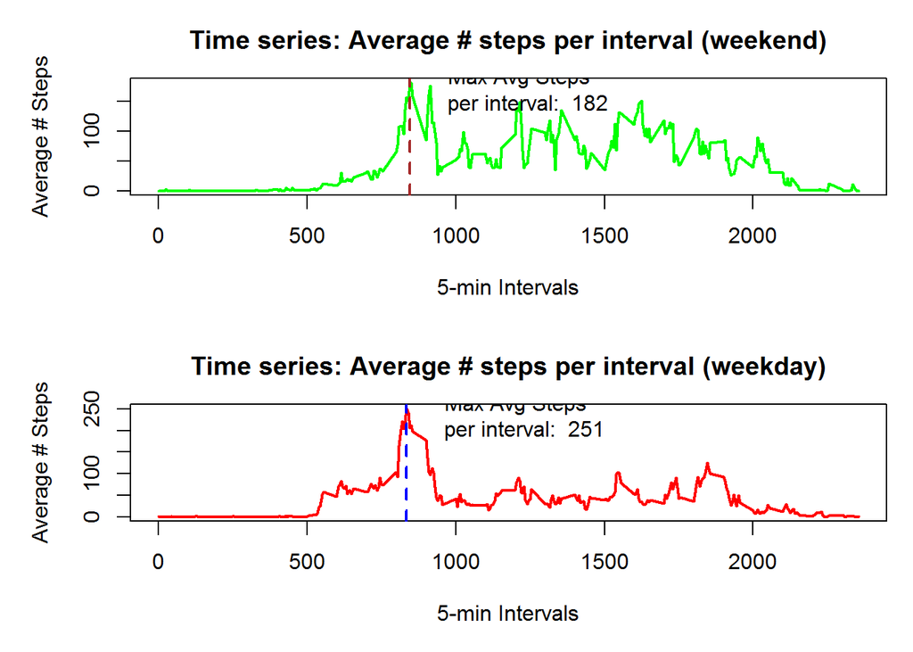

```r
df_avg_steps_per_intv_wend <-aggregate(steps ~ interval, data=dt_Act_All[weekend_ind=="weekend",], mean)
df_avg_steps_per_intv_wday <-aggregate(steps ~ interval, data=dt_Act_All[weekend_ind=="weekday",], mean)

## png(filename="plot1-4 Panel time-series plot .png", width=640, height=640, units="px")
par(mfrow=c(2,1), mar=c(5,5,3,1))
with(df_avg_steps_per_intv_wend,
     plot(interval, steps, type="l", col="green", lwd=2,
          main="Time series: Average # steps per interval (weekend)",
          ylab="Average # Steps", xlab="5-min Intervals")
)
maxRowWend <- df_avg_steps_per_intv_wend[which.max(df_avg_steps_per_intv_wend$steps),]
maxRowWend$steps <- round(maxRowWend$steps,0)
abline(v=maxRowWend[1], col="brown", lwd=2, lty=2)
text(x=maxRowWend[1]*1.1, y=maxRowWend[2]*0.9, paste("Max Avg Steps \nper interval: ", round(maxRowWend[2],0)), pos=4)

with(df_avg_steps_per_intv_wday,
     plot(interval, steps, type="l", col="red", lwd=2,
          main="Time series: Average # steps per interval (weekday)",
          ylab="Average # Steps", xlab="5-min Intervals")
)
maxRowWday <- df_avg_steps_per_intv_wday[which.max(df_avg_steps_per_intv_wday$steps),]
maxRowWday$steps <- round(maxRowWday$steps,0)
abline(v=maxRowWday[1], col="blue", lwd=2, lty=2)
text(x=maxRowWday[1]*1.1, y=maxRowWday[2]*0.9, paste("Max Avg Steps \nper interval: ", round(maxRowWday[2],0)), pos=4)
```

```r
## dev.off()
```

# THANK YOU :)